# Segundo Parcial - Ejercicio Practico

Gonzalo Barrera Borla

July 3, 2019

Comezamos cargando los datos, estimando el modelo completo y graficando residuos estandarizados (estudentizados internos) versus predichos:

```r
datos1 <- read.table("datos1.txt")
n <- dim(datos1)[1]
df <- as_tibble(datos1, rownames = "obs")
modelo_completo <- y ~ x1 + x2 + x3 + x4
llamada_lm <- lm(modelo_completo, data = df)
df <- broom::augment(llamada_lm, df)
```

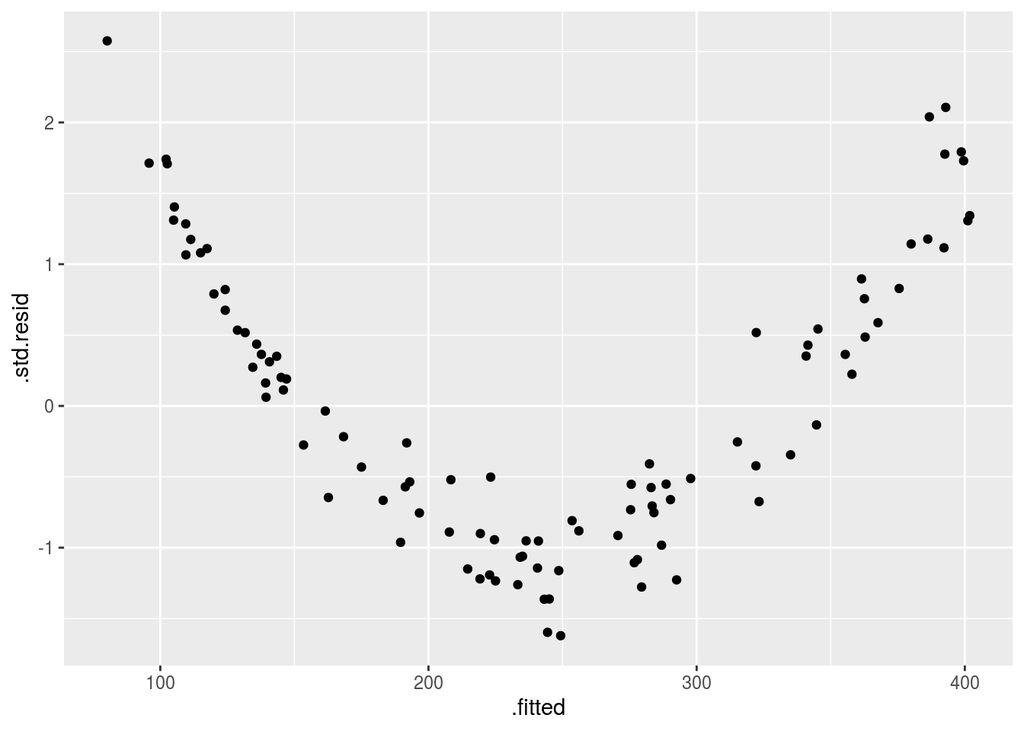

```r
(grafico_b <- ggplot(df, aes(x=.fitted, y=.std.resid)) +
  geom_point())
```

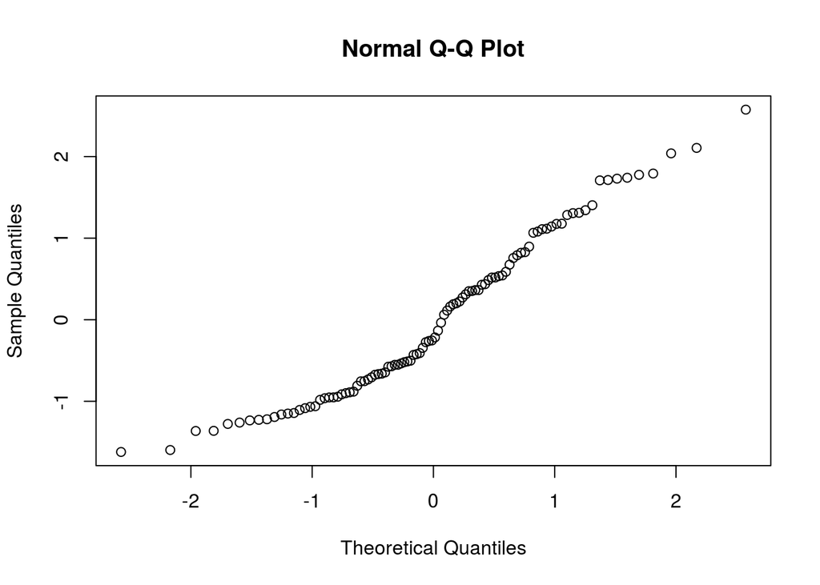

```r
qqnorm(df$.std.resid)
```

No veo exactamente una recta, pero no me queda muy claro qué veo. Rehago el gráfico con `ggplot2` para mayor claridad:

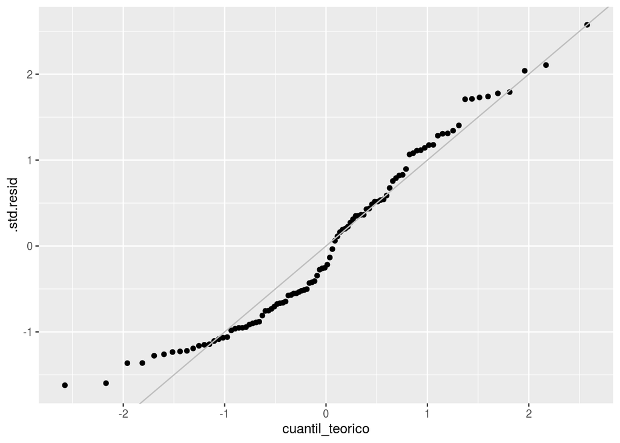

```r
(grafico_cbis <- df %>%
  arrange(.std.resid) %>%
  mutate(
    cuantil_teorico = qnorm((seq(n)-0.5)/n)) %>%
  ggplot(aes(cuantil_teorico, .std.resid)) +
  geom_point() +
  geom_abline(slope=1, intercept=0, color='gray'))
```

```r
alfa <- 0.05
llamada_shapiro <- shapiro.test(df$.std.resid)
```

El test nos da un p-valor de 0.0010242, con lo cual SÍ tenemos suficiente evidencia como para rechazar la hipótesis nula de que los datos tienen una distribución subyacente normal.

Cuando tenemos evidencia tan fuerte de la no-normalidad de los errores (y por ende de la variable respuesta), un potencial “arreglo” consiste en postular una familia de transformaciones (ya sea para la respuesta y/o las covariables), y encontrar dentro de ellas la que “mejor normaliza” los datos. En particular, proponemos la familia de transformaciones Box-Cox, para la respuesta
$$y^{(\lambda)}=g(y,\lambda)=\begin{cases}
\ln(y) &\quad \text{si } \lambda=0 \\
(y^{\lambda}-1) /{\lambda} &\quad\text{si } \lambda \neq 0\\
\end{cases}$$

```r
llamada_boxcox <- boxcox(modelo_completo, data = df)
```

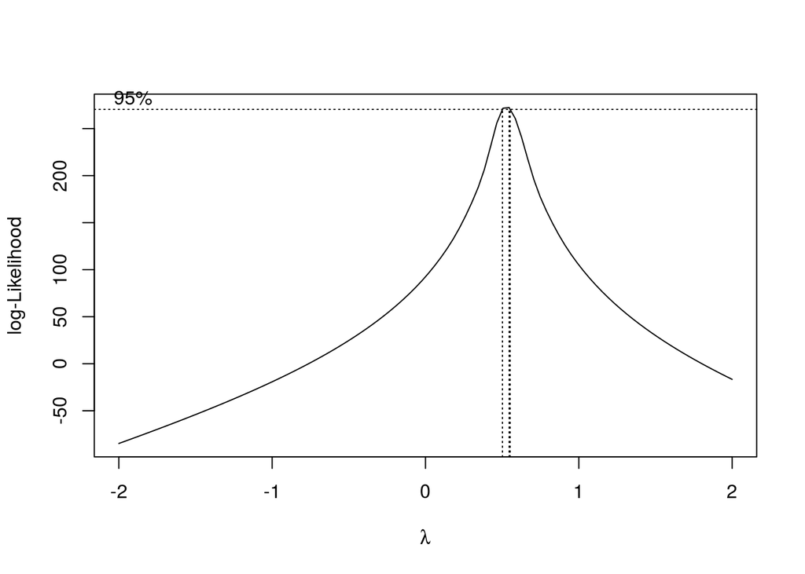

```r
lambda <- llamada_boxcox$x[which.max(llamada_boxcox$y)]
```

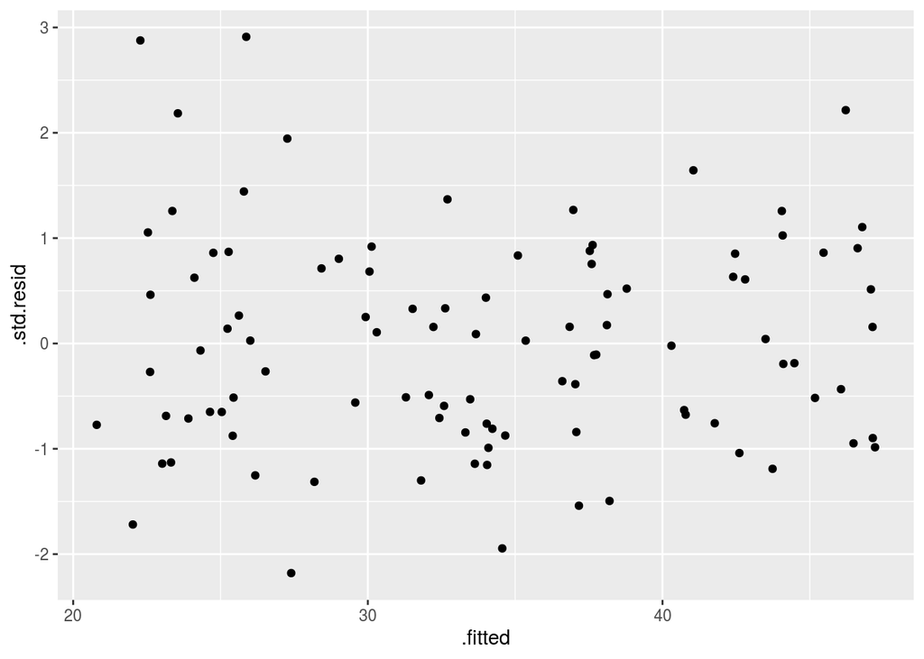

```r
g_boxcox <- function(y, lambda) {
  if (lambda == 0) {
    return(log(y))
  } else {
    return((y^lambda - 1) / lambda)
  }
}

df_lambda <- as_tibble(datos1, rownames = "obs") %>%
  mutate(y_lambda = g_boxcox(y, lambda))

modelo_transformado <- y_lambda ~ x1 + x2 + x3 + x4
llamada_lm_transformado <- lm(modelo_transformado, df_lambda)
df_lambda <- augment(llamada_lm_transformado)
(grafico_d <- ggplot(df_lambda, aes(x=.fitted, y=.std.resid)) +
  geom_point())
```

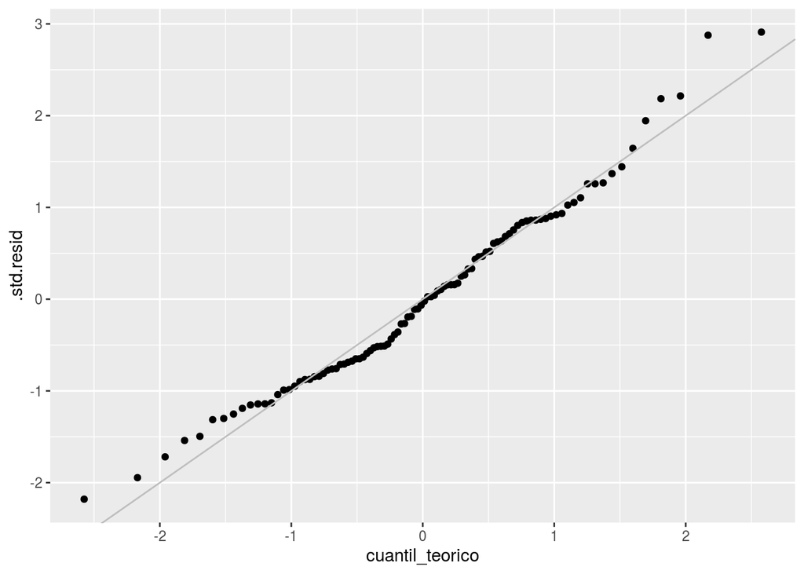

```r
(grafico_dbis <- df_lambda %>%
  arrange(.std.resid) %>%
  mutate(
    cuantil_teorico = qnorm((seq(n)-0.5)/n)) %>%
  ggplot(aes(cuantil_teorico, .std.resid)) +
  geom_point() +
  geom_abline(slope=1, intercept=0, color='gray'))
```

```r
llamada_shapiro_lambda <- shapiro.test(df_lambda$.std.resid)
```

La medida $C_p$ de Mallow para el modelo $i$ se define como
$$C_{p,i}\frac{RSS_{p,i}}{s^2}+2p-n$$

```r
covariables <- c("x1","x2","x3","x4")

generar_formulas <- function(p, y_nombre, X_nombre) {
  lados_derechos <- unlist(
      combn(x = X_nombre, m = p,
            simplify = F, FUN = paste, collapse = " + "))

  map(str_c(y_nombre, "~", lados_derechos, sep = " "), as.formula)
}

modelos <- map(seq_len(4),
                generar_formulas,
                y_nombre = "y_lambda",
                X_nombre = covariables) %>%
  imap(~ tibble("p" = .y, "modelo" = .x)) %>%
  bind_rows %>%
  mutate(nombre = map(modelo, deparse) %>% map_chr(str_c, collapse = ""))

modelos <- modelos %>%
  mutate(
    ajuste = map(modelo, lm, data=df_lambda),
    resumen = map(ajuste, glance),
    adj_r_sq = map_dbl(resumen, "adj.r.squared"))

adj_r_sq_full <- modelos %>%
  filter(nombre == "y_lambda ~ x1 + x2 + x3 + x4") %>%
  pluck("adj_r_sq")

calcular_cp <- function(adj_r_sq, p, adj_r_sq_full, n) {
  return((1-adj_r_sq)*(n-p)/(1-adj_r_sq_full)-n+2*p)
}

modelos <- modelos %>%
  mutate(
    cp = map2_dbl(adj_r_sq, p, calcular_cp, adj_r_sq_full=adj_r_sq_full, n=n)
  )

mejor_modelo_cp <- top_n(modelos, 1, -cp)
```

Este procedimiento, aplicado a todos los modelos, nos recomienda elegir y_lambda ~ x1 + x2 + x3, que tiene un $C_p$ de 2.4708207, ligeramente mejor que el modelo completo.

Si siguieramos un criterio de *selección hacia adelante*, deberíamos ir agregando variables de a una al modelo “base” únicamente con ordenada, siempre y cuando $R^2_{adj,p+1} \geq R^2_{adj,p}$. Reutilizando la tabla del punto anterior:

```r
modelos %>%
  dplyr::select(nombre, adj_r_sq, cp) %>%
  arrange(-adj_r_sq)
```

```
## # A tibble: 15 x 3
##    nombre                       adj_r_sq        cp
##    <chr>                           <dbl>     <dbl>
##  1 y_lambda ~ x1 + x2 + x3       1.000        2.47
##  2 y_lambda ~ x1 + x2 + x3 + x4  1.000        4
##  3 y_lambda ~ x1 + x3            1.000       70.5
##  4 y_lambda ~ x1 + x3 + x4       1.000       72.5
##  5 y_lambda ~ x1 + x2            0.997      935.
##  6 y_lambda ~ x1 + x2 + x4       0.997      934.
##  7 y_lambda ~ x1                 0.997     1050.
##  8 y_lambda ~ x1 + x4            0.997     1051.
##  9 y_lambda ~ x2 + x4            0.918    32314.
## 10 y_lambda ~ x2 + x3 + x4       0.918    31999.
## 11 y_lambda ~ x2 + x3            0.918    32480.
## 12 y_lambda ~ x2                 0.918    32824.
## 13 y_lambda ~ x3                -0.00425 402640.
## 14 y_lambda ~ x4                -0.00971 404828.
## 15 y_lambda ~ x3 + x4           -0.0142  402528.
```

Se ve que la primera covariable a agregar debería ser $x_1$, seguida por $x_3$, y el modelo de 2 variables propuesto sería $\{x_1,x_3\}$.

```r
(matriz_corr <- cor(df_lambda[,covariables]))
```

```
##             x1          x2          x3          x4
## x1  1.00000000  0.95482551 -0.02761955 -0.02105989
## x2  0.95482551  1.00000000 -0.04951062  0.01404968
## x3 -0.02761955 -0.04951062  1.00000000  0.03372418
## x4 -0.02105989  0.01404968  0.03372418  1.00000000
```

Es notorio que las variables $x_1,x_2$ estan fuertemente correlacionadas, y por ende tal vez no sea del todo sabio elegir como modelo el propuesto por el critero de $C_p$, $\{x_1, x_2, x_3\}$. Se puede ver que este ultimo solo mejora el cuarto decimal del $R^2_{adj}$, y es poco probable que estos resultados se puedan reproducir tan fielmente en otra muestra. Bajo esta suposicion, preferimos quedarnos con el modelo $\{x_1,x_3\}$:

$$y = \beta_0 + \beta_1 x_1 + \beta_3 x_3 + \epsilon$$

Para la segunda muestra, repetimos todo el procedimiento, manteniendo el $\lambda$ elegido y el mejor modelo seleccionado.

```r
datos2 <- read.table("datos2.txt")
n <- dim(datos2)[1]

df2 <- as_tibble(datos2, rownames = "obs") %>%
  mutate(y_lambda = g_boxcox(y, lambda))
# a)
modelo_elegido <- y_lambda ~ x1 + x3
llamada_lm2 <- lm(modelo_elegido, data = df2)
summary(llamada_lm2)
```

```
##
## Call:
## lm(formula = modelo_elegido, data = df2)
##
## Residuals:
##     Min      1Q  Median      3Q     Max
## -39.990  -0.283   0.682   1.860   4.044
##
## Coefficients:
##             Estimate Std. Error t value Pr(>|t|)
## (Intercept)   1.9062     1.9804   0.963   0.3370
## x1            2.1759     0.1270  17.137   <2e-16 ***
## x3           -0.4365     0.1728  -2.526   0.0123 *
## ---
## Signif. codes:  0 '***' 0.001 '**' 0.01 '*' 0.05 '.' 0.1 ' ' 1
##
## Residual standard error: 5.184 on 197 degrees of freedom
## Multiple R-squared:  0.6033, Adjusted R-squared:  0.5993
## F-statistic: 149.8 on 2 and 197 DF,  p-value: < 2.2e-16
```

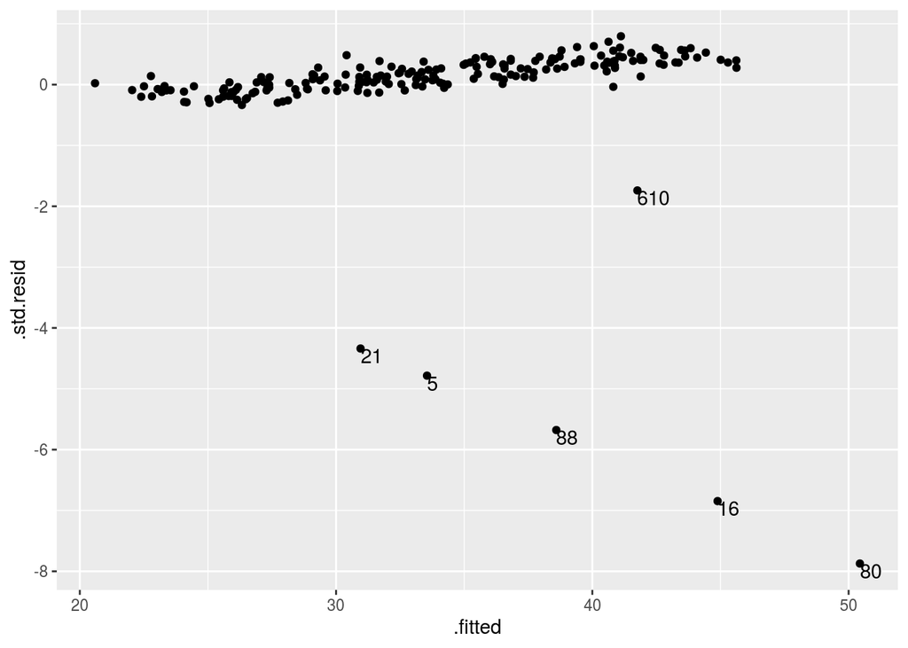

```r
df2 <- broom::augment(llamada_lm2, df2)

(grafico_ii <- ggplot(df2, aes(x=.fitted, y=.std.resid)) +
  geom_point() +
  geom_text(aes(label = obs), data = df2[df2$.std.resid < -1,],
            hjust=0, vjust=1))
```

A *grosso modo*, las observaciones $(5,16,21,80,88,610)$ tienen residuos estandarizados sospechosamente altos. Una forma de ver si son outliers, es considerar su *leverage*:

```r
df2 %>%
  dplyr::select(obs, y, .fitted, .hat, .std.resid) %>%
  arrange(desc(.hat)) %>%
  top_n(10, .hat)
```

```
## # A tibble: 10 x 5
##    obs       y .fitted   .hat .std.resid
##    <chr> <dbl>   <dbl>  <dbl>      <dbl>
##  1 610   221.     41.8 0.0555    -1.74
##  2 49     99.5    20.6 0.0477     0.0227
##  3 821   318.     40.8 0.0467    -0.0365
##  4 43    149.     27.7 0.0440    -0.298
##  5 74    219.     30.4 0.0432     0.483
##  6 94    411.     45.6 0.0413     0.277
##  7 561   123.     22.8 0.0411     0.141
##  8 551   133.     26.3 0.0410    -0.335
##  9 80     32.7    50.4 0.0400    -7.87
## 10 211   383.     41.1 0.0380     0.795
```

Vemos que algunos de los candidatos a outliers tienen alto *leverage*, pero no todos, ni tampoco todos los puntos de alto *leverage* tienen residuos tan grandes, con lo cual el análisis es poco concluyente. Una alternativa, es realizar un ajuste robusto de este mismo modelo, y ver para qué observaciones el peso resultante tiende a 0.

```r
control <- lmrobdet.control(efficiency = 0.9, family = "bisquare")
llamada_lmrob <- lmrobdetMM(modelo_elegido, df2, control=control)

df2 <- df2 %>%
  mutate(pesos_rob = llamada_lmrob$rweights)

df2 %>%
  dplyr::select(obs, y, .fitted, x1, x3, pesos_rob, .std.resid, .hat) %>%
  arrange(pesos_rob) %>%
  filter(pesos_rob < 0.1)
```

```
## # A tibble: 11 x 8
##    obs       y .fitted    x1     x3 pesos_rob .std.resid    .hat
##    <chr> <dbl>   <dbl> <dbl>  <dbl>     <dbl>      <dbl>   <dbl>
##  1 5      25.2    33.5  15.2  3.39     0          -4.78  0.00672
##  2 8     116.     24.1  10.0 -0.813    0          -0.285 0.0299
##  3 16     30.9    44.9  20.9  5.53     0          -6.85  0.0377
##  4 21     24.0    31.0  14.0  3.21     0          -4.34  0.00693
##  5 43    149.     27.7  11.2 -3.08     0          -0.298 0.0440
##  6 80     32.7    50.4  22.7  1.94     0          -7.87  0.0400
##  7 88     27.2    38.6  17.2  1.64     0          -5.68  0.00802
##  8 610   221.     41.8  19.9  7.9      0          -1.74  0.0555
##  9 551   133.     26.3  10.7 -2.57     0          -0.335 0.0410
## 10 93    109.     22.8  10.4  3.89     0.0192     -0.193 0.0215
## 11 67    126.     25.0  10.6 -0.223    0.0760     -0.235 0.0232
```

Bajo este criterio, las observaciones propuestas originalmente como *outliers* se identifican como tales, y también aparecen otras 3 nuevas: $(8,43,551)$, que en el análisis original estaban “enmascaradas” por el excesivos peso de los *outliers* más evidentes. Además, las observaciones $93$ y $67$, están en una dudosa frontera.